# 2_quartiles_VI

được viết bởi

Ellie Nguyen

Tứ phân vị

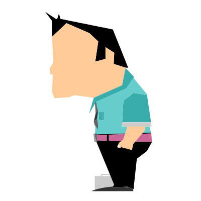

Mai e hèm:

- Giả sử tôi có số liệu về mức lương của hai công ty như sau:

Mico: $$\$1 000 000,\$37 000 ,\$48 000 ,\$35 000, \$50 000, \$90 000,$$

$$ \$45000 ,\$60 000 ,\$42 000 ,\$74000 ,\$72 000 $$

Gogog:

$$ \$1 500 000 ,\$38 000, \$60 000,\$87 000 ,\$52 000 ,$$ $$ \$95 000 ,\$45000 ,\$78 000 ,\$41 000, \$74000 $$

Nếu sau này cậu đi xin việc thì cậu nghĩ dựa trên năng lực của bản thân, cậu nghĩ lương của mình nằm ở mức nào?

Hắn cười tươi rói:

- *Khiêm tốn* mà nói thì tôi nghĩ là mình ở mức trung bình!

Mai cười:

- Người ta thường có xu hướng đánh giá bản thân cao hơn so với thực tế. Nên, tôi nghĩ nếu anh đã nói vậy thì anh nên tìm hiểu về phân vị thứ nhất của dữ liệu về mức lương!
- À, đúng rồi! Một người như tôi thì xứng đáng với …những cái “nhất”!
- Ha…ha…Biết phân vị thứ nhất (1st quantile) là cái gì không?
- Là cái gì? Là một trong những người có mức lương cao nhất đúng không?

Mai:

- Ha…ha…ha! Sao ngốc quá vậy! Khi ta sắp xếp số liệu theo thứ tự từ bé đến lớn thì **trung vị** (trung là ở giữa, vị là vị trí) là điểm chính giữa, chia bộ dữ liệu thành hai phần với kích cỡ bằng nhau. Trong đó, một phần có tất cả các giá trị bé hơn hoặc bằng trung vị, một phần có tất cả các giá trị lớn hơn hoặc bằng trung vị.

Ví dụ: Đối với số liệu về mức lương của Mico

$$\$1 000 000 ,\$37 000 ,\$48 000 ,\$35 000 ,\$50 000$$$$\$90000 ,\$45000 ,\$60 000 ,\$42 000 ,\$74000 ,\$72 000$$

Nếu ta sắp số liệu theo thứ tự từ bé đến lớn thì được

$$\$35 000 , \$37 000 , \$42 000 ,\$ 45 000, \$48 000 ,\$ 50000 ,$$$$\$ 60 000 ,\$72 000 ,\$74 000 , \$90 000 , ,\$1 000 000$$

Bộ dữ liệu này có 11 quan sát (observations). Thì quan sát ở chính giữa nằm ở vị trí thứ 6 trong bộ dữ liệu đã được sắp xếp, tức là $\$50000$. Như vậy, trung vị bằng $\$50 000$.

Nhưng đối với số liệu của Gogog: $$\$1 500 000 ,\$38 000 ,\$60 000 ,\$87 000 ,\$52 000 ,$$

$$\$95000 ,\$45000 ,\$78 000 ,\$41 000 ,\$74000$$

Thì khi sắp số liệu theo thứ tự từ bé đến lớn ta được $$\$38 000 , \$41 000 ,\$ 45 000 , \$52 000 ,\$ 60 000 ,$$

$$\$ 74 000 ,\$78 000 , \$87 000 , \$95 000 ,\$1 500 000 $$

Trung vị (Median) = $\frac{60 000 + 74 000}{2}= 67000$

Nhưng dĩ nhiên, đối với nhiều người, trong đó có cậu thì tìm hiểu về median là không đủ hoặc không cần thiết! Do đó, người ta đưa ra khái niệm tứ phân vị (quantiles). Nếu trung vị chẻ đôi dữ liệu thành 2 phần với kích cỡ bằng nhau; một phần có tất cả các giá trị bé hơn hoặc bằng trung vị, một phần có tất cả các giá trị lớn hơn hoặc bằng trung vị; thì với mỗi phần nhỏ trong hai phần đó, nếu ta tiếp tục chẻ đôi theo kiểu như vậy thì lần lượt sẽ được phân vị thứ nhất (1st quantile) và phân vị thứ ba(3rd quantile). Còn trung vị thì còn được gọi là phân vị thứ hai (2nd quantile).

Đến đây thì Mai cười như không nhịn được:

- Như vậy thì phân vị thứ nhất sẽ giúp anh tìm hiểu về những người có mức lương nằm ở… mức thấp nhất trong công ty!

Parker:

- Cô xỏ tôi hả?
- Đâu có! Nếu lương cậu bằng 1st quantile thì anh đã có mức lương lớn hơn hoặc bằng 25% những người trong công ty rồi còn gì? Hi…hi…!

Parker:

- Vậy 75% những người còn lại có lương cao hơn tôi còn gì?

Mai cười nham nhở:

- Đúng rồi!!!

Mai:

- Vậy cứ xem như là năng lực của anh là ở mức trung bình đi! Vậy thì khi đi xin việc anh sẽ nhìn vào trung bình (mean) của mức lương hay median?

Parker:

- Chắc là trung bình! Tôi thấy thiên hạ người ta hay dùng cái đó!

Mai:

- Năng lực của cậu trung bình mà xin mức lương bằng trung bình của lương của tất cả mọi người trong công ty thì ai dám nhận cậu?

Parker:

- Tại sao?

Parker:

- Ờ, ha…ha…!